# Major_Project

## OBSERVATIONS:

- 2014 Year based cars are more in number. And cars from year 2015 and 2016 are almost same.
- Diesel cars are more than petrol. LPG is negligble.
- 5 No. of seats are more then comes 7.
- Manual Transmission are more than automatic transmission.
- First Class Owner type are more than second then third and then fourth. Fourth and above is very less.
- Most Owner prefer manual transmission.
- Fuel Type of 5 seater are more because of more number of 5 seat type. In that also petrol type is more than diesel.
- LPG fuel type is negligble.
- Power of automatic type are more than manual.
- Engine of automatic type vehicles are more than manual.
- Mileage of manual type is more than automatic type.
- Price of automatic type transmission is more than manual.
- 1000-2000 cc capacity of engines are more.
- Price range is far more for first class owner type then any other type.
- 100-200 bhp power cars are more and has priced their cars between 60k.

### Inferences made from data visualization

- Outliers present in Kilometers_Driven.
- Outliers present in Mileage and Power.
- Name, Location columns does not have any significant values in the dataset.
- Owners prefers manual type over automatic type because :
  - **Mileage is more in manual type transmission**.
  - **Price is less for manual type cars**.
- When it comes to performance automatic type cars performs better than manual cars.
- Manual cars are more than automatic cars.
- **For models we need to clear the outliers first otherwise the model will not be accurate.**

## Identification of outliers and removal.

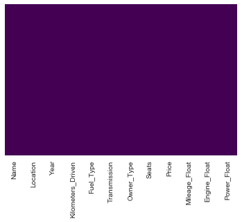

```python
sns.heatmap(expr.isnull(),yticklabels=False,cbar= False,cmap = 'viridis')
#This indicates we dont have any null values.
```

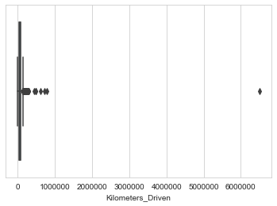

```python
sns.boxplot(x ='Kilometers_Driven',data = expr)
```

Clearly it is visible that it contains a outlier.

```python
Q1 = expr.Kilometers_Driven.quantile(0.25)
print(Q1)
Q3 = expr.Kilometers_Driven.quantile(0.75)
print(Q3)
IQR = Q3 - Q1
print(IQR)
print(Q1 - (1.5 * IQR))
print(Q3 + (1.5 * IQR))
```

```
33908.0
73000.0
39092.0
-24730.0
131638.0
```

```python
expr[~((expr.Kilometers_Driven < (Q1 - 1.5 * IQR)) |(expr.Kilometers_Driven > (Q3 + 1.5 * IQR)))].Kilometers_Driven.median()
```

```
52000.0
```

```python
index = expr[(expr['Kilometers_Driven'] >= 1000000)].index
expr.drop(index, inplace=True)
```

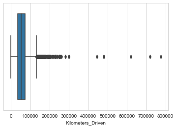

```python
sns.boxplot(x ='Kilometers_Driven',data = expr)
```

Since now we can see more precision in outliers we can remove them as well.

```python
index = expr[(expr['Kilometers_Driven'] >= 200000)].index
expr.drop(index, inplace=True)
```

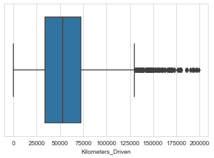

```python
sns.boxplot(x ='Kilometers_Driven',data = expr)
```

These points cannot be considered as outliers now because they are more in number and removing it will cost accuracy of the dataset.

**Now checking outliers from the Mileage column.**

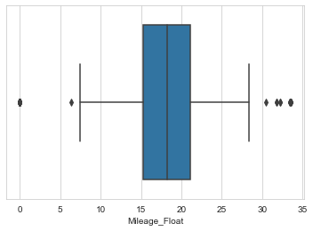

```python
sns.boxplot(x ='Mileage_Float',data = expr)
```

```python
index = expr[(expr['Mileage_Float'] <=10)].index
expr.drop(index, inplace=True)
```

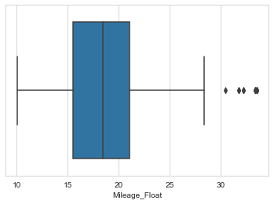

```python
sns.boxplot(x ='Mileage_Float',data = expr)
```

```python
index = expr[(expr['Mileage_Float'] >=25)].index
expr.drop(index, inplace=True)
```

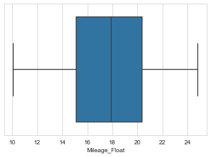

```python
sns.boxplot(x ='Mileage_Float',data = expr)
```

Outliers are removed from the Mileage also.

**Now checking outliers from Power Column.**

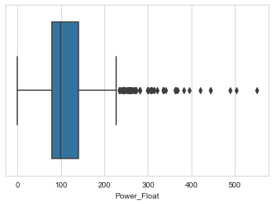

```python
sns.boxplot(x ='Power_Float',data = expr)
```

```python
Q1 = expr.Power_Float.quantile(0.25)
print(Q1)
Q3 = expr.Power_Float.quantile(0.75)
print(Q3)
IQR = Q3 - Q1
print(IQR)
print(Q1 - (1.5 * IQR))
print(Q3 + (1.5 * IQR))
```

```
78.9
140.0
61.099999999999994
-12.749999999999986
231.64999999999998
```

```python
expr[~((expr.Power_Float < (Q1 - 1.5 * IQR)) |(expr.Power_Float > (Q3 + 1.5 * IQR)))].Power_Float.median()
```

```
90.0
```

```python
index = expr[(expr['Power_Float'] >=300)].index
expr.drop(index, inplace=True)
```

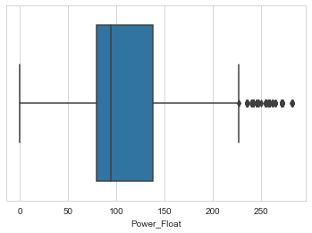

```python
sns.boxplot(x ='Power_Float',data = expr)
```

```python
index = expr[(expr['Power_Float'] >=260)].index
expr.drop(index, inplace=True)
```

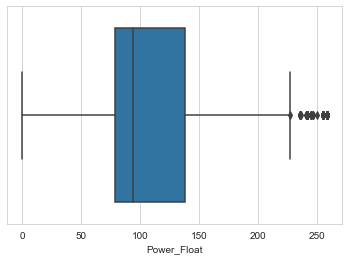

```python
sns.boxplot(x ='Power_Float',data = expr)
```

If we want we can completely remove these outliers if we go in the range 230-250 but doing so will cost a large number of data points to go missing and will result in accuracy so we will keep it like this.

### **Now we have removed the outliers so we can go for machine learning for model predictions.**

# MACHINE LEARNING ALGORITHMS FOR PREDICTIONS

Since from the data visualization it was quite clear that the transmission column and owner type column is playing an important role in the dataset so we will have to consider it as well. But it is a **string based** column so we will create some dummy variable to satisfy the needs of a machine learning model as machine learning model does not understand the String based text.

```python
cleanup_nums = {"Transmission":     {"Manual": 0, "Automatic": 1},
                "Owner_Type": {"First": 1, "Second": 2, "Third": 3, "Fourth & Above": 4},
                "Fuel_Type": {"Diesel": 1, "Petrol": 2, "CNG": 3, "LPG": 4},
               }
```

```python
expr.replace(cleanup_nums, inplace=True)
expr.head()
```

|  | Name | Location | Year | Kilometers_Driven | Fuel_Type | Transmission | Owner_Type | Seats | Price | Mileage_Float | Engine_Float | Power_Float |
| --- | --- | --- | --- | --- | --- | --- | --- | --- | --- | --- | --- | --- |
| 1 | Hyundai Creta 1.6 CRDi SX Option | Pune | 2015 | 41000 | 1 | 0 | 1 | 5.0 | 12.50 | 19.67 | 1582.0 | 126.20 |
| 2 | Honda Jazz V | Chennai | 2011 | 46000 | 2 | 0 | 1 | 5.0 | 4.50 | 18.20 | 1199.0 | 88.70 |
| 3 | Maruti Ertiga VDI | Chennai | 2012 | 87000 | 1 | 0 | 1 | 7.0 | 6.00 | 20.77 | 1248.0 | 88.76 |
| 4 | Audi A4 New 2.0 TDI Multitronic | Coimbatore | 2013 | 40670 | 1 | 1 | 2 | 5.0 | 17.74 | 15.20 | 1968.0 | 140.80 |
| 5 | Hyundai EON LPG Era Plus Option | Hyderabad | 2012 | 75000 | 4 | 0 | 1 | 5.0 | 2.35 | 21.10 | 814.0 | 55.20 |

```python
expr.columns.tolist()
```

```
['Name',
 'Location',
 'Year',
 'Kilometers_Driven',
 'Fuel_Type',
 'Transmission',
 'Owner_Type',
 'Seats',
 'Price',
 'Mileage_Float',
 'Engine_Float',
 'Power_Float']
```

```python
expr.info()
```

```
<class 'pandas.core.frame.DataFrame'>
Int64Index: 5311 entries, 1 to 6017
Data columns (total 12 columns):
 #   Column             Non-Null Count  Dtype
---  ------             --------------  -----
 0   Name               5311 non-null   object
 1   Location           5311 non-null   object
 2   Year               5311 non-null   int64
 3   Kilometers_Driven  5311 non-null   int64
 4   Fuel_Type          5311 non-null   int64
 5   Transmission       5311 non-null   int64
 6   Owner_Type         5311 non-null   int64
 7   Seats              5311 non-null   float64
 8   Price              5311 non-null   float64
 9   Mileage_Float      5311 non-null   float64
 10  Engine_Float       5311 non-null   float64
 11  Power_Float        5311 non-null   float64
dtypes: float64(5), int64(5), object(2)
memory usage: 539.4+ KB
```

**Now we will change the order of the dataframe so that the target column is at the last of the dataset. And also we will get rid of the useless column like name and location.**

```python
expr = expr[['Name','Location','Year','Kilometers_Driven','Fuel_Type','Transmission','Owner_Type','Seats','Mileage_Float','Engine_Float','Power_Float','Price']]
```

```python
expr.head()
```

|  | Name | Location | Year | Kilometers_Driven | Fuel_Type | Transmission | Owner_Type | Seats | Mileage_Float | Engine_Float | Power_Float | Price |
| --- | --- | --- | --- | --- | --- | --- | --- | --- | --- | --- | --- | --- |
| 1 | Hyundai Creta 1.6 CRDi SX Option | Pune | 2015 | 41000 | 1 | 0 | 1 | 5.0 | 19.67 | 1582.0 | 126.20 | 12.50 |
| 2 | Honda Jazz V | Chennai | 2011 | 46000 | 2 | 0 | 1 | 5.0 | 18.20 | 1199.0 | 88.70 | 4.50 |
| 3 | Maruti Ertiga VDI | Chennai | 2012 | 87000 | 1 | 0 | 1 | 7.0 | 20.77 | 1248.0 | 88.76 | 6.00 |
| 4 | Audi A4 New 2.0 TDI Multitronic | Coimbatore | 2013 | 40670 | 1 | 1 | 2 | 5.0 | 15.20 | 1968.0 | 140.80 | 17.74 |
| 5 | Hyundai EON LPG Era Plus Option | Hyderabad | 2012 | 75000 | 4 | 0 | 1 | 5.0 | 21.10 | 814.0 | 55.20 | 2.35 |

```python
expr.drop('Name',axis=1,inplace = True)
```

```python
expr.drop('Location',axis=1,inplace =True)
```

```python
expr.head()
```

|  | Year | Kilometers_Driven | Fuel_Type | Transmission | Owner_Type | Seats | Mileage_Float | Engine_Float | Power_Float | Price |
| --- | --- | --- | --- | --- | --- | --- | --- | --- | --- | --- |
| 1 | 2015 | 41000 | 1 | 0 | 1 | 5.0 | 19.67 | 1582.0 | 126.20 | 12.50 |
| 2 | 2011 | 46000 | 2 | 0 | 1 | 5.0 | 18.20 | 1199.0 | 88.70 | 4.50 |
| 3 | 2012 | 87000 | 1 | 0 | 1 | 7.0 | 20.77 | 1248.0 | 88.76 | 6.00 |
| 4 | 2013 | 40670 | 1 | 1 | 2 | 5.0 | 15.20 | 1968.0 | 140.80 | 17.74 |
| 5 | 2012 | 75000 | 4 | 0 | 1 | 5.0 | 21.10 | 814.0 | 55.20 | 2.35 |

##### Now we will fit our data for the training and testing purpose.

```python
X = expr[['Year','Kilometers_Driven','Fuel_Type','Transmission','Owner_Type','Seats','Mileage_Float','Engine_Float','Power_Float']]
```

```python
y = expr['Price']
```

```python
from sklearn.model_selection import train_test_split
```

```python
X_train,X_test,y_train,y_test = train_test_split(X,y,test_size= 0.3,random_state = 101)
```

### **FIRST MODEL WE WILL APPLY IS LINEAR REGRESSION**

```python
from sklearn.linear_model import LinearRegression
```

```python
lm = LinearRegression()
```

```python
lm.fit(X_train,y_train)
```

```
LinearRegression(copy_X=True, fit_intercept=True, n_jobs=None, normalize=False)
```

```python
lm.coef_
```

```
array([ 7.19824676e-01, -3.52025184e-05, -2.82770065e+00,  3.16480285e+00,
       -4.48940259e-02, -8.41924044e-01, -1.68290615e-01,  2.41201350e-03,
        9.43691729e-02])
```

```python
X_train.columns
```

```
Index(['Year', 'Kilometers_Driven', 'Fuel_Type', 'Transmission', 'Owner_Type',
       'Seats', 'Mileage_Float', 'Engine_Float', 'Power_Float'],
      dtype='object')
```

```python
cdf = pd.DataFrame(lm.coef_,X.columns,columns=['coeff'])
```

```python
pred = lm.predict(X_test)
```

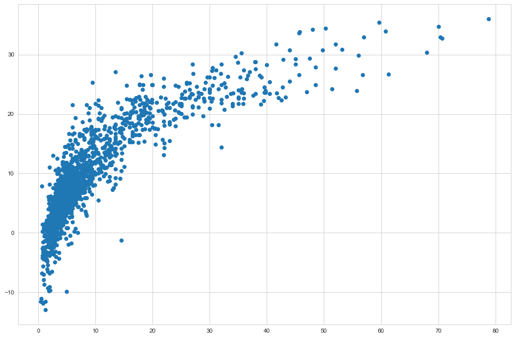

```python
plt.figure(figsize = (15,10))
plt.scatter(y_test,pred)
```

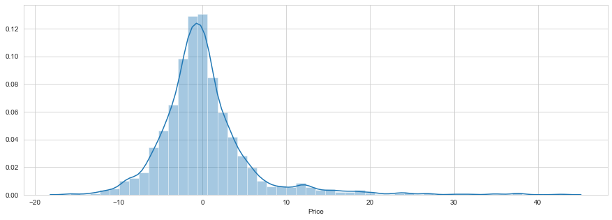

```python
plt.figure(figsize = (15,5))
sns.distplot((y_test-pred))
```

```python
from sklearn import metrics
```

```python
print('MAE:', metrics.mean_absolute_error(y_test, pred))
print('MSE:', metrics.mean_squared_error(y_test, pred))
print('RMSE:', np.sqrt(metrics.mean_squared_error(y_test, pred)))
```

```
MAE: 3.5997218932270134
MSE: 32.057123228268814
RMSE: 5.661901026004323
```

### **SECOND MODEL WILL BE DECISION TREE**

```python
from sklearn.model_selection import train_test_split
```

```python
X = expr.drop('Price',axis = 1)
```

```python
y = expr['Price']
```

```python
X_train,X_test,y_train,y_test = train_test_split(X,y,test_size=0.3,random_state = 31)
```

```python
from sklearn.tree import DecisionTreeRegressor
```

```python
dtree = DecisionTreeRegressor()
```

```python
dtree.fit(X_train,y_train)
```

```
DecisionTreeRegressor(ccp_alpha=0.0, criterion='mse', max_depth=None,
                      max_features=None, max_leaf_nodes=None,
                      min_impurity_decrease=0.0, min_impurity_split=None,
                      min_samples_leaf=1, min_samples_split=2,
                      min_weight_fraction_leaf=0.0, presort='deprecated',
                      random_state=None, splitter='best')
```

```python
pred = dtree.predict(X_test)
```

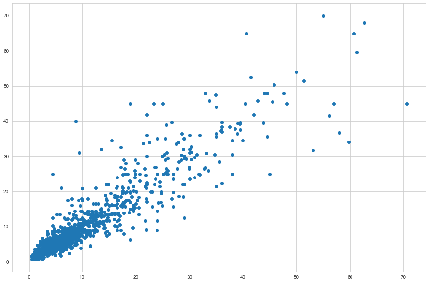

```python
plt.figure(figsize = (15,10))
plt.scatter(y_test,pred)
```

```python
from sklearn import metrics
```

```python
print('MAE:', metrics.mean_absolute_error(y_test, pred))
print('MSE:', metrics.mean_squared_error(y_test, pred))
print('RMSE:', np.sqrt(metrics.mean_squared_error(y_test, pred)))
```

```
MAE: 1.8820294855708908
MSE: 12.953050486198247
RMSE: 3.5990346603218826
```

### THIRD MODEL WILL BE RANDOM FOREST

```python
from sklearn.ensemble import RandomForestRegressor
```

```python
rfr = RandomForestRegressor(n_estimators=200)
```

```python
rfr.fit(X_train,y_train)
```

```
RandomForestRegressor(bootstrap=True, ccp_alpha=0.0, criterion='mse',
                      max_depth=None, max_features='auto', max_leaf_nodes=None,
                      max_samples=None, min_impurity_decrease=0.0,
                      min_impurity_split=None, min_samples_leaf=1,
                      min_samples_split=2, min_weight_fraction_leaf=0.0,
                      n_estimators=200, n_jobs=None, oob_score=False,
                      random_state=None, verbose=0, warm_start=False)
```

```python
rfr_pred = rfr.predict(X_test)
```

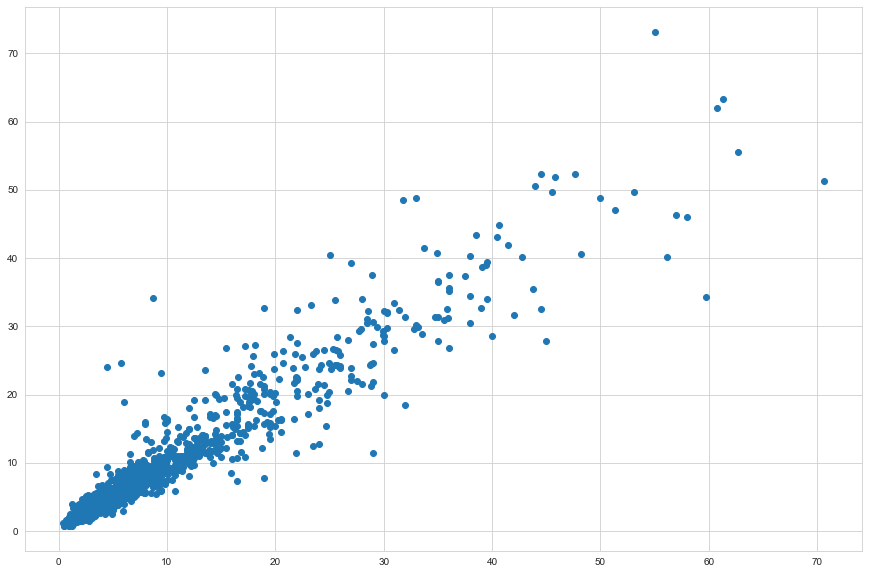

```python
plt.figure(figsize = (15,10))
plt.scatter(y_test,rfr_pred)
```

```python
print('MAE:', metrics.mean_absolute_error(y_test, rfr_pred))
print('MSE:', metrics.mean_squared_error(y_test, rfr_pred))
print('RMSE:', np.sqrt(metrics.mean_squared_error(y_test, rfr_pred)))
```

```
MAE: 1.4615373080973295
MSE: 7.904102242315784
RMSE: 2.811423525959009
```

### FOURTH MODEL WILL BE KNN

```python
from sklearn.preprocessing import StandardScaler
```

```python
scaler = StandardScaler()
```

```python
scaler.fit(expr.drop('Price',axis =1))
```

```
StandardScaler(copy=True, with_mean=True, with_std=True)
```

```python
scaled_features = scaler.transform(expr.drop('Price',axis = 1))
```

```python
expr_feat = pd.DataFrame(scaled_features,columns = expr.columns[:-1])
```

```python
expr_feat.head()
```

|  | Year | Kilometers_Driven | Fuel_Type | Transmission | Owner_Type | Seats | Mileage_Float | Engine_Float | Power_Float |
| --- | --- | --- | --- | --- | --- | --- | --- | --- | --- |
| 0 | 0.515031 | -0.490386 | -0.961120 | -0.639630 | -0.446039 | -0.388354 | 0.519210 | -0.050253 | 0.338978 |
| 1 | -0.720857 | -0.332682 | 0.982715 | -0.639630 | -0.446039 | -0.388354 | 0.097054 | -0.755699 | -0.452550 |
| 2 | -0.411885 | 0.960491 | -0.961120 | -0.639630 | -0.446039 | 2.102645 | 0.835110 | -0.665446 | -0.451284 |
| 3 | -0.102913 | -0.500794 | -0.961120 | 1.563403 | 1.778293 | -0.388354 | -0.764490 | 0.660718 | 0.647147 |
| 4 | -0.411885 | 0.582001 | 4.870385 | -0.639630 | -0.446039 | -0.388354 | 0.929880 | -1.464828 | -1.159649 |

```python
X_train, X_test, y_train, y_test = train_test_split(scaled_features,expr['Price'],
                                                    test_size=0.30)
```

```python
from sklearn.neighbors import KNeighborsRegressor
```

```python
knn = KNeighborsRegressor(n_neighbors=1)
```

```python
#Assuming the value of k =1
```

```python
knn.fit(X_train,y_train)
```

```
KNeighborsRegressor(algorithm='auto', leaf_size=30, metric='minkowski',
                    metric_params=None, n_jobs=None, n_neighbors=1, p=2,
                    weights='uniform')
```

```python
pred = knn.predict(X_test)
```

```python
print('MAE:', metrics.mean_absolute_error(y_test, pred))
print('MSE:', metrics.mean_squared_error(y_test, pred))
print('RMSE:', np.sqrt(metrics.mean_squared_error(y_test, pred)))
```

```
MAE: 1.9256524466750313
MSE: 14.883871204516941
RMSE: 3.8579620532759185
```

```python
#The RMSE here is 3.857 so we will try to find the best suited value for k so that the error becomes less.
```

```python
error_rate = []
for i in range(1,40):
    knn = KNeighborsRegressor(n_neighbors=i)
    knn.fit(X_train,y_train)
    pred_i = knn.predict(X_test)
    error_rate.append(np.mean(pred_i != y_test))
```

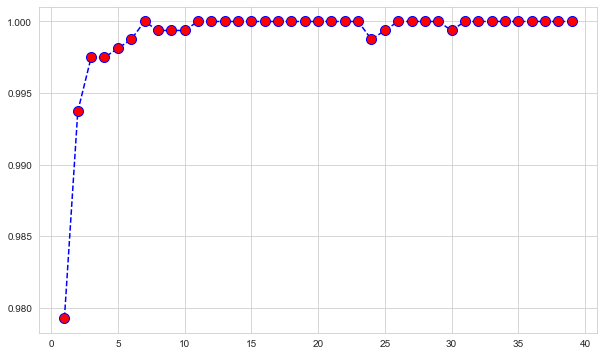

```python
plt.figure(figsize = (10,6))
plt.plot(range(1,40),error_rate,color = 'blue',linestyle = 'dashed',marker = 'o',markerfacecolor='red', markersize=10)
```

```python
#By looking at the graph it is observed that the error will keep on increasing for higher values. So we will use k =3
```

```python
knn = KNeighborsRegressor(n_neighbors=3)
knn.fit(X_train,y_train)
```

```
KNeighborsRegressor(algorithm='auto', leaf_size=30, metric='minkowski',
                    metric_params=None, n_jobs=None, n_neighbors=3, p=2,
                    weights='uniform')
```

```python
pred = knn.predict(X_test)
```

```python
print('MAE:', metrics.mean_absolute_error(y_test, pred))
print('MSE:', metrics.mean_squared_error(y_test, pred))
print('RMSE:', np.sqrt(metrics.mean_squared_error(y_test, pred)))
```

```
MAE: 1.8619719782517774
MSE: 13.611031193364003
RMSE: 3.6893131058997963
```

```python
#RMSE changed from 3.85 to 3.68 which is not a big difference but anyways!
```